# Wrangling using R

Vivek Vijayaraghavan

4/4/2019

# 1 Data Wrangling

## 1.1 Overview

Data wrangling is the process of cleaning and unifying messy and complex data sets for easy access and analysis. With the amount of data and data sources rapidly growing and expanding, it is getting more and more essential for the large amounts of available data to be organized for analysis. This process typically includes manually converting/mapping data from one raw form into another format to allow for more convenient consumption and organization of the data.

## 1.2 Pre-Requisites

As part of the data wrangling, we will focus on how to use the dplyr package, which is a core member of the tidyverse. We will use ggplot2 to highlight nay visualization and also primarily work on the nycflights13 package as dataset, We would use additional datasets as and when appropriate to highlight certain concepts.

```r
library(tidyverse)
library(nycflights13)
data(flights)
str(flights)
```

```
## Classes 'tbl_df', 'tbl' and 'data.frame':    336776 obs. of  19 variables:
##  $ year          : int  2013 2013 2013 2013 2013 2013 2013 2013 2013 2013 ...
##  $ month         : int  1 1 1 1 1 1 1 1 1 1 ...
##  $ day           : int  1 1 1 1 1 1 1 1 1 1 ...
##  $ dep_time      : int  517 533 542 544 554 554 555 557 557 558 ...
##  $ sched_dep_time: int  515 529 540 545 600 558 600 600 600 600 ...
##  $ dep_delay     : num  2 4 2 -1 -6 -4 -5 -3 -3 -2 ...
##  $ arr_time      : int  830 850 923 1004 812 740 913 709 838 753 ...
##  $ sched_arr_time: int  819 830 850 1022 837 728 854 723 846 745 ...
##  $ arr_delay     : num  11 20 33 -18 -25 12 19 -14 -8 8 ...
##  $ carrier       : chr  "UA" "UA" "AA" "B6" ...
##  $ flight        : int  1545 1714 1141 725 461 1696 507 5708 79 301 ...
##  $ tailnum       : chr  "N14228" "N24211" "N619AA" "N804JB" ...
##  $ origin        : chr  "EWR" "LGA" "JFK" "JFK" ...
##  $ dest          : chr  "IAH" "IAH" "MIA" "BQN" ...
##  $ air_time      : num  227 227 160 183 116 150 158 53 140 138 ...
##  $ distance      : num  1400 1416 1089 1576 762 ...
##  $ hour          : num  5 5 5 5 6 5 6 6 6 6 ...
##  $ minute        : num  15 29 40 45 0 58 0 0 0 0 ...
##  $ time_hour     : POSIXct, format: "2013-01-01 05:00:00" "2013-01-01 05:00:00" ...
```

## 1.3 dplyr core functions

In this section we will learn 5 key dplyr functions that will allow to solve the vast majority of data manipulation challenges. They are: - Pick obervations by their values (filter()) - Reorder the rows (arrange()) - Pick variables by their names (select()) - Create new variables with functions of existing variables (mutate()) - Collapse many values down to a single summary (summarize())

The r code snippet that highlights the above functions are listed below:

```r
# Filter flights for a specific day
# Note the format / syntax for comparisons is ==
f1 <- filter(flights, month == 1, day ==1)
head(f1)
```

| year | month | day | dep_time | sched_dep_time | dep_delay | arr_time | sched_arr_time | arr_delay | carrier | flight | tailnum | origin | dest | air_time | distance | hour | minute | time_hour |
| --- | --- | --- | --- | --- | --- | --- | --- | --- | --- | --- | --- | --- | --- | --- | --- | --- | --- | --- |
| 2013 | 1 | 1 | 517 | 515 | 2 | 830 | 819 | 11 | UA | 1545 | N14228 | EWR | IAH | 227 | 1400 | 5 | 15 | 2013-01-01 05:00:00 |
| 2013 | 1 | 1 | 533 | 529 | 4 | 850 | 830 | 20 | UA | 1714 | N24211 | LGA | IAH | 227 | 1416 | 5 | 29 | 2013-01-01 05:00:00 |
| 2013 | 1 | 1 | 542 | 540 | 2 | 923 | 850 | 33 | AA | 1141 | N619AA | JFK | MIA | 160 | 1089 | 5 | 40 | 2013-01-01 05:00:00 |
| 2013 | 1 | 1 | 544 | 545 | -1 | 1004 | 1022 | -18 | B6 | 725 | N804JB | JFK | BQN | 183 | 1576 | 5 | 45 | 2013-01-01 05:00:00 |
| 2013 | 1 | 1 | 554 | 600 | -6 | 812 | 837 | -25 | DL | 461 | N668DN | LGA | ATL | 116 | 762 | 6 | 0 | 2013-01-01 06:00:00 |
| 2013 | 1 | 1 | 554 | 558 | -4 | 740 | 728 | 12 | UA | 1696 | N39463 | EWR | ORD | 150 | 719 | 5 | 58 | 2013-01-01 05:00:00 |

```r
# Multiple arguments in teh filter can be combined using the set opertaions - and, or etc
f2 <- filter(flights, month == 11 & month == 12)
head(f2)
```

| year | month | day | dep_time | sched_dep_time | dep_delay | arr_time | sched_arr_time | arr_delay | carrier | flight | tailnum | origin | dest | air_time | distance | hour | minute | time_hour |
| --- | --- | --- | --- | --- | --- | --- | --- | --- | --- | --- | --- | --- | --- | --- | --- | --- | --- | --- |

```r
# OR Clause
f3 <- filter(flights, month == 11 | month == 12)
head(f3)
```

| year | month | day | dep_time | sched_dep_time | dep_delay | arr_time | sched_arr_time | arr_delay | carrier | flight | tailnum | origin | dest | air_time | distance | hour | minute | time_hour |
| --- | --- | --- | --- | --- | --- | --- | --- | --- | --- | --- | --- | --- | --- | --- | --- | --- | --- | --- |
| 2013 | 11 | 1 | 5 | 2359 | 6 | 352 | 345 | 7 | B6 | 745 | N568JB | JFK | PSE | 205 | 1617 | 23 | 59 | 2013-11-01 23:00:00 |
| 2013 | 11 | 1 | 35 | 2250 | 105 | 123 | 2356 | 87 | B6 | 1816 | N353JB | JFK | SYR | 36 | 209 | 22 | 50 | 2013-11-01 22:00:00 |
| 2013 | 11 | 1 | 455 | 500 | -5 | 641 | 651 | -10 | US | 1895 | N192UW | EWR | CLT | 88 | 529 | 5 | 0 | 2013-11-01 05:00:00 |
| 2013 | 11 | 1 | 539 | 545 | -6 | 856 | 827 | 29 | UA | 1714 | N38727 | LGA | IAH | 229 | 1416 | 5 | 45 | 2013-11-01 05:00:00 |
| 2013 | 11 | 1 | 542 | 545 | -3 | 831 | 855 | -24 | AA | 2243 | N5CLAA | JFK | MIA | 147 | 1089 | 5 | 45 | 2013-11-01 05:00:00 |
| 2013 | 11 | 1 | 549 | 600 | -11 | 912 | 923 | -11 | UA | 303 | N595UA | JFK | SFO | 359 | 2586 | 6 | 0 | 2013-11-01 06:00:00 |

```r
# Exercise problem
# Find all flights that had an arrival delay of more than 2 hours, flew to Houston (IAH or HOU) and were operated by United, American or Delta
f4 <- filter(flights, arr_delay >= 120 & (dest %in% c("IAH","HOU")) & carrier %in% c("UA","AA","DL"))
str(f4)
```

```
## Classes 'tbl_df', 'tbl' and 'data.frame':    162 obs. of  19 variables:
##  $ year          : int  2013 2013 2013 2013 2013 2013 2013 2013 2013 2013 ...
##  $ month         : int  1 1 1 1 1 1 1 10 10 10 ...
##  $ day           : int  1 10 15 16 20 21 31 3 10 11 ...
##  $ dep_time      : int  1114 2137 1603 1239 2136 1708 2123 1122 2018 2009 ...
##  $ sched_dep_time: int  900 1630 1446 1043 1700 1446 1856 630 1720 1720 ...
##  $ dep_delay     : num  134 307 77 116 276 142 147 292 178 169 ...
##  $ arr_time      : int  1447 17 1957 1558 27 2032 49 1357 2241 2233 ...
##  $ sched_arr_time: int  1222 1925 1757 1340 2011 1757 2204 919 2010 2010 ...
##  $ arr_delay     : num  145 292 120 138 256 155 165 278 151 143 ...
##  $ carrier       : chr  "UA" "UA" "UA" "UA" ...
##  $ flight        : int  1086 1178 337 575 602 337 891 1454 652 404 ...
##  $ tailnum       : chr  "N76502" "N75435" "N819UA" "N667UA" ...
##  $ origin        : chr  "LGA" "EWR" "LGA" "EWR" ...
##  $ dest          : chr  "IAH" "IAH" "IAH" "IAH" ...
##  $ air_time      : num  248 197 242 224 213 239 234 193 176 179 ...
##  $ distance      : num  1416 1400 1416 1400 1416 ...
##  $ hour          : num  9 16 14 10 17 14 18 6 17 17 ...
##  $ minute        : num  0 30 46 43 0 46 56 30 20 20 ...
##  $ time_hour     : POSIXct, format: "2013-01-01 09:00:00" "2013-01-10 16:00:00" ...
```

```r
# Use arrange to sort the rows by ascending or descending
# ascending order is by default and missing values are sorted to the end
f5 <- arrange(flights, year, month, desc(day))
head(f5)
```

| year | month | day | dep_time | sched_dep_time | dep_delay | arr_time | sched_arr_time | arr_delay | carrier | flight | tailnum | origin | dest | air_time | distance | hour | minute | time_hour |
| --- | --- | --- | --- | --- | --- | --- | --- | --- | --- | --- | --- | --- | --- | --- | --- | --- | --- | --- |
| 2013 | 1 | 31 | 1 | 2100 | 181 | 124 | 2225 | 179 | WN | 530 | N550WN | LGA | MDW | 127 | 725 | 21 | 0 | 2013-01-31 21:00:00 |
| 2013 | 1 | 31 | 4 | 2359 | 5 | 455 | 444 | 11 | B6 | 739 | N599JB | JFK | PSE | 206 | 1617 | 23 | 59 | 2013-01-31 23:00:00 |
| 2013 | 1 | 31 | 7 | 2359 | 8 | 453 | 437 | 16 | B6 | 727 | N505JB | JFK | BQN | 197 | 1576 | 23 | 59 | 2013-01-31 23:00:00 |
| 2013 | 1 | 31 | 12 | 2250 | 82 | 132 | 7 | 85 | B6 | 30 | N178JB | JFK | ROC | 60 | 264 | 22 | 50 | 2013-01-31 22:00:00 |
| 2013 | 1 | 31 | 26 | 2154 | 152 | 328 | 50 | 158 | B6 | 515 | N663JB | EWR | FLL | 161 | 1065 | 21 | 54 | 2013-01-31 21:00:00 |
| 2013 | 1 | 31 | 34 | 2159 | 155 | 135 | 2315 | 140 | EV | 4162 | N24128 | EWR | BTV | 43 | 266 | 21 | 59 | 2013-01-31 21:00:00 |

```r
# select function to select specific columns or variables
f6 <- select(flights, flight, year, month, day)
head(f6)
```

| flight | year | month | day |
| --- | --- | --- | --- |
| 1545 | 2013 | 1 | 1 |
| 1714 | 2013 | 1 | 1 |
| 1141 | 2013 | 1 | 1 |
| 725 | 2013 | 1 | 1 |
| 461 | 2013 | 1 | 1 |
| 1696 | 2013 | 1 | 1 |

```r
# add new varaibles using mutate
f7 <- select(flights, flight, year:day, ends_with("time"), distance, ends_with("delay"))
f8 <- mutate(f7, duration = arr_time - dep_time, speed = distance/air_time)
head(select(f8, duration, speed, everything()))
```

| duration | speed | flight | year | month | day | dep_time | sched_dep_time | arr_time | sched_arr_time | air_time | distance | dep_delay | arr_delay |
| --- | --- | --- | --- | --- | --- | --- | --- | --- | --- | --- | --- | --- | --- |
| 313 | 6.167401 | 1545 | 2013 | 1 | 1 | 517 | 515 | 830 | 819 | 227 | 1400 | 2 | 11 |
| 317 | 6.237885 | 1714 | 2013 | 1 | 1 | 533 | 529 | 850 | 830 | 227 | 1416 | 4 | 20 |
| 381 | 6.806250 | 1141 | 2013 | 1 | 1 | 542 | 540 | 923 | 850 | 160 | 1089 | 2 | 33 |
| 460 | 8.612022 | 725 | 2013 | 1 | 1 | 544 | 545 | 1004 | 1022 | 183 | 1576 | -1 | -18 |
| 258 | 6.568966 | 461 | 2013 | 1 | 1 | 554 | 600 | 812 | 837 | 116 | 762 | -6 | -25 |
| 186 | 4.793333 | 1696 | 2013 | 1 | 1 | 554 | 558 | 740 | 728 | 150 | 719 | -4 | 12 |

```r
# group and summarize
f9 <- group_by(flights, year, month, day)
f10 <- summarize(f9, delay = mean(dep_delay, na.rm = TRUE))
tail(f10)
```

| year | month | day | delay |
| --- | --- | --- | --- |
| 2013 | 12 | 26 | 14.417204 |
| 2013 | 12 | 27 | 10.937630 |
| 2013 | 12 | 28 | 7.981550 |
| 2013 | 12 | 29 | 22.309551 |
| 2013 | 12 | 30 | 10.698113 |
| 2013 | 12 | 31 | 6.996053 |

## 1.4 References

- [Data Watch] (https://www.datawatch.com/what-is-data-wrangling/)
- R for Data Science - Hadley Wickham & Garrett Grolemund
- [Tidy Data](https://r4ds.had.co.nz/tidy-data.html)
- [Case Study](https://rpubs.com/mm-c/gather-and-spread)

# 2 Tidy Data

Tidy data is a consistent organization mechanism to organize data in R. tidyr is a package that provides a bunch of tools to help tidy up messy datasets. tidyr is a memebr of the code tidyverse. There are three inherent rules that makes a dataset tidy: - Each variable must have its own column - Each observation muct have its own row - Each value must have its own cell.

To make better plots, it is important to tidy the data. It is also importatnt that we do not try to make the visualizations complex, because we do not want to tidy our data. In the example, below, we show one way to tidy the iris data and then the subsequent visualizations become simpler.

```r
# Load the tidyr package
library(tidyr)

# Original iris dataset
str(iris)
```

```
## 'data.frame':    150 obs. of  5 variables:
##  $ Sepal.Length: num  5.1 4.9 4.7 4.6 5 5.4 4.6 5 4.4 4.9 ...
##  $ Sepal.Width : num  3.5 3 3.2 3.1 3.6 3.9 3.4 3.4 2.9 3.1 ...
##  $ Petal.Length: num  1.4 1.4 1.3 1.5 1.4 1.7 1.4 1.5 1.4 1.5 ...
##  $ Petal.Width : num  0.2 0.2 0.2 0.2 0.2 0.4 0.3 0.2 0.2 0.1 ...
##  $ Species     : Factor w/ 3 levels "setosa","versicolor",..: 1 1 1 1 1 1 1 1 1 1 ...
```

```r
# Tidy the iris data. Includes gathering data around Species and splitting the data by part and measure.
iris.tidy <- iris %>%
  gather(key, Value, -Species) %>%
  separate(key, c("Part", "Measure"), "\\.")

str(iris.tidy)
```

```
## 'data.frame':    600 obs. of  4 variables:
##  $ Species: Factor w/ 3 levels "setosa","versicolor",..: 1 1 1 1 1 1 1 1 1 1 ...
##  $ Part   : chr  "Sepal" "Sepal" "Sepal" "Sepal" ...
##  $ Measure: chr  "Length" "Length" "Length" "Length" ...
##  $ Value  : num  5.1 4.9 4.7 4.6 5 5.4 4.6 5 4.4 4.9 ...
```

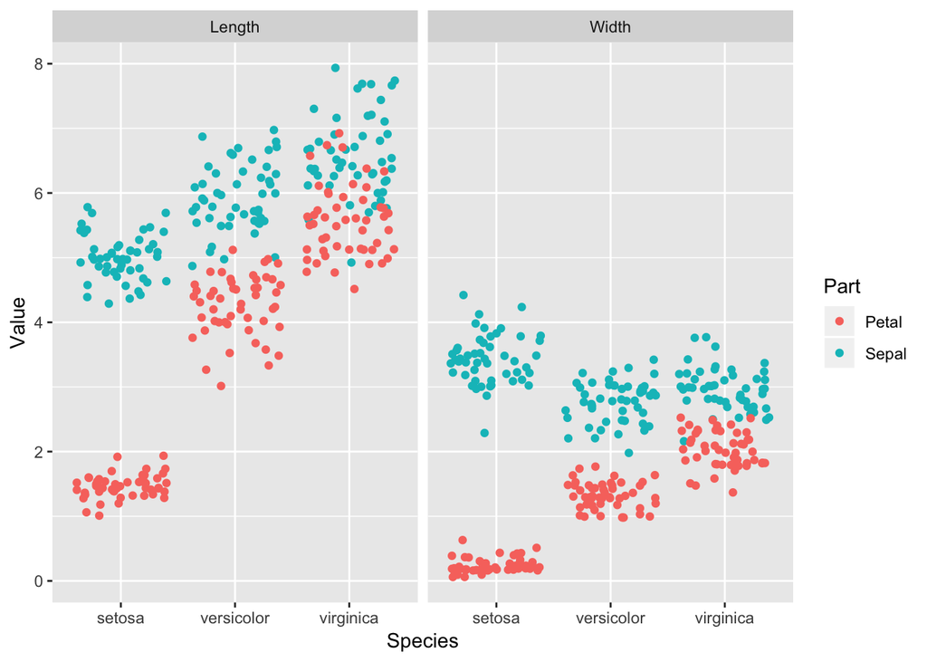

```r
# Now the visualization in ggplot can be reduced to
ggplot(iris.tidy, aes(x = Species, y = Value, col = Part)) +
  geom_jitter() +
  facet_grid(. ~ Measure)
```

## 2.1 Unique

We can use the unique function to get a distinct values in a dataset variable. For example, in iris dataset to get unique values of the species we ca:

```r
str(iris)
```

```
## 'data.frame':    150 obs. of  5 variables:
##  $ Sepal.Length: num  5.1 4.9 4.7 4.6 5 5.4 4.6 5 4.4 4.9 ...
##  $ Sepal.Width : num  3.5 3 3.2 3.1 3.6 3.9 3.4 3.4 2.9 3.1 ...
##  $ Petal.Length: num  1.4 1.4 1.3 1.5 1.4 1.7 1.4 1.5 1.4 1.5 ...
##  $ Petal.Width : num  0.2 0.2 0.2 0.2 0.2 0.4 0.3 0.2 0.2 0.1 ...
##  $ Species     : Factor w/ 3 levels "setosa","versicolor",..: 1 1 1 1 1 1 1 1 1 1 ...
```

```r
print("Unique values of the species are...")
```

```
## [1] "Unique values of the species are..."
```

```r
unique(iris$Species)
```

```
## [1] setosa     versicolor virginica
## Levels: setosa versicolor virginica
```

## 2.2 Gathering & Spreading

One of the most common scenario encountered is to udnerstand if the data contains rows when it should be columns and viceversa. We will use the three core characteristics of the tidy data to clean some messy data. There are two commands we can use to moving rows to columns and columns to rows. They are: - gather (move columns into rows) - spread (move rows into columns)

To highlight the above two functions, we will go ahead and get messy sample data and then use these functions to tidy the data. In the example below, we will see that the raw data contains: - The years are in columns, which is fine for side-by-side eyeballing, but terrible for charting or similar - The patient bed days and separations counts are muddled together.

In this case we will do the following: - Move all of the years into one column and - seperate patient days and seperations as variables (columns) from rows.

```r
# data showing the general reasons people were admitted to hospital
# by financial year from July 1993 to June 1998.
rsns <- read_csv("http://www.mm-c.me/mdsi/hospitals93to98.csv")
str(rsns)
```

```
## Classes 'tbl_df', 'tbl' and 'data.frame':    38 obs. of  8 variables:
##  $ IcdChapter: chr  "0. Not Reported" "0. Not Reported" "1. Infectious and Parasitic Diseases" "1. Infectious and Parasitic Diseases" ...
##  $ Field     : chr  "PatientDays" "Separations" "PatientDays" "Separations" ...
##  $ FY1993    : num  257965 37178 311221 75857 1686919 ...
##  $ FY1994    : num  55582 6146 313386 78323 1707437 ...
##  $ FY1995    : num  128507 3832 324693 84631 1795751 ...
##  $ FY1996    : num  182226 4861 311560 80864 1770559 ...
##  $ FY1997    : num  61599 1558 306688 79148 1777452 ...
##  $ FY1998    : num  685879 53575 1567548 398823 8738118 ...
##  - attr(*, "spec")=List of 2
##   ..$ cols   :List of 8
##   .. ..$ IcdChapter: list()
##   .. .. ..- attr(*, "class")= chr  "collector_character" "collector"
##   .. ..$ Field     : list()
##   .. .. ..- attr(*, "class")= chr  "collector_character" "collector"
##   .. ..$ FY1993    : list()
##   .. .. ..- attr(*, "class")= chr  "collector_number" "collector"
##   .. ..$ FY1994    : list()
##   .. .. ..- attr(*, "class")= chr  "collector_number" "collector"
##   .. ..$ FY1995    : list()
##   .. .. ..- attr(*, "class")= chr  "collector_number" "collector"
##   .. ..$ FY1996    : list()
##   .. .. ..- attr(*, "class")= chr  "collector_number" "collector"
##   .. ..$ FY1997    : list()
##   .. .. ..- attr(*, "class")= chr  "collector_number" "collector"
##   .. ..$ FY1998    : list()
##   .. .. ..- attr(*, "class")= chr  "collector_number" "collector"
##   ..$ default: list()
##   .. ..- attr(*, "class")= chr  "collector_guess" "collector"
##   ..- attr(*, "class")= chr "col_spec"
```

```r
head(rsns)
```

| IcdChapter | Field | FY1993 | FY1994 | FY1995 | FY1996 | FY1997 | FY1998 |
| --- | --- | --- | --- | --- | --- | --- | --- |
| 0. Not Reported | PatientDays | 257965 | 55582 | 128507 | 182226 | 61599 | 685879 |
| 0. Not Reported | Separations | 37178 | 6146 | 3832 | 4861 | 1558 | 53575 |
| 1. Infectious and Parasitic Diseases | PatientDays | 311221 | 313386 | 324693 | 311560 | 306688 | 1567548 |
| 1. Infectious and Parasitic Diseases | Separations | 75857 | 78323 | 84631 | 80864 | 79148 | 398823 |
| 2. Neoplasms | PatientDays | 1686919 | 1707437 | 1795751 | 1770559 | 1777452 | 8738118 |
| 2. Neoplasms | Separations | 301928 | 336447 | 348905 | 360578 | 378070 | 1725928 |

```r
rsns_tidy <- rsns %>%
  gather(year,value,FY1993:FY1998) %>%
  spread(Field,value)

str(rsns_tidy)
```

```
## Classes 'tbl_df', 'tbl' and 'data.frame':    114 obs. of  4 variables:
##  $ IcdChapter : chr  "0. Not Reported" "0. Not Reported" "0. Not Reported" "0. Not Reported" ...
##  $ year       : chr  "FY1993" "FY1994" "FY1995" "FY1996" ...
##  $ PatientDays: num  257965 55582 128507 182226 61599 ...
##  $ Separations: num  37178 6146 3832 4861 1558 ...
```

```r
head(rsns_tidy)
```

| IcdChapter | year | PatientDays | Separations |
| --- | --- | --- | --- |
| 0. Not Reported | FY1993 | 257965 | 37178 |
| 0. Not Reported | FY1994 | 55582 | 6146 |
| 0. Not Reported | FY1995 | 128507 | 3832 |
| 0. Not Reported | FY1996 | 182226 | 4861 |
| 0. Not Reported | FY1997 | 61599 | 1558 |
| 0. Not Reported | FY1998 | 685879 | 53575 |

## 2.3 Seperating & Pulling

In the untidy datasets, we will encounter situations where a variable (column) that can have multiple values. Similarly, we could also have the inverse situation, where we have multiple columns that have partitions of the same variable. We will use sepearte and pull functions to help tidy this data.

```r
# We will artificially merge multiple columns in wage data to show how to seperate and pull data together.
library('ISLR')
data(Wage) #Load the builtin dataset Wage.
# head(Wage) # Top 6 rows of the dataset Wage.

#wage_untidy contains one column called details that has merged three unique details to create untidy data.
wage_untidy <- Wage %>% unite(details, maritl, race, education, sep="/")
print("Untidy Data...")
```

```
## [1] "Untidy Data..."
```

```r
str(wage_untidy)
```

```
## 'data.frame':    3000 obs. of  9 variables:
##  $ year      : int  2006 2004 2003 2003 2005 2008 2009 2008 2006 2004 ...
##  $ age       : int  18 24 45 43 50 54 44 30 41 52 ...
##  $ details   : chr  "1. Never Married/1. White/1. < HS Grad" "1. Never Married/1. White/4. College Grad" "2. Married/1. White/3. Some College" "2. Married/3. Asian/4. College Grad" ...
##  $ region    : Factor w/ 9 levels "1. New England",..: 2 2 2 2 2 2 2 2 2 2 ...
##  $ jobclass  : Factor w/ 2 levels "1. Industrial",..: 1 2 1 2 2 2 1 2 2 2 ...
##  $ health    : Factor w/ 2 levels "1. <=Good","2. >=Very Good": 1 2 1 2 1 2 2 1 2 2 ...
##  $ health_ins: Factor w/ 2 levels "1. Yes","2. No": 2 2 1 1 1 1 1 1 1 1 ...
##  $ logwage   : num  4.32 4.26 4.88 5.04 4.32 ...
##  $ wage      : num  75 70.5 131 154.7 75 ...
```

```r
head(wage_untidy)
```

|  | year | age | details | region | jobclass | health | health_ins | logwage | wage |
| --- | --- | --- | --- | --- | --- | --- | --- | --- | --- |
| 231655 | 2006 | 18 | 1. Never Married/1. White/1. < HS Grad | 2. Middle Atlantic | 1. Industrial | 1. <=Good | 2. No | 4.318063 | 75.04315 |
| 86582 | 2004 | 24 | 1. Never Married/1. White/4. College Grad | 2. Middle Atlantic | 2. Information | 2. >=Very Good | 2. No | 4.255273 | 70.47602 |
| 161300 | 2003 | 45 | 2. Married/1. White/3. Some College | 2. Middle Atlantic | 1. Industrial | 1. <=Good | 1. Yes | 4.875061 | 130.98218 |
| 155159 | 2003 | 43 | 2. Married/3. Asian/4. College Grad | 2. Middle Atlantic | 2. Information | 2. >=Very Good | 1. Yes | 5.041393 | 154.68529 |
| 11443 | 2005 | 50 | 4. Divorced/1. White/2. HS Grad | 2. Middle Atlantic | 2. Information | 1. <=Good | 1. Yes | 4.318063 | 75.04315 |
| 376662 | 2008 | 54 | 2. Married/1. White/4. College Grad | 2. Middle Atlantic | 2. Information | 2. >=Very Good | 1. Yes | 4.845098 | 127.11574 |

```r
# Tidy data to seperate the details columns into three seperate columns
wage_tidy <- wage_untidy %>% separate(details, into = c("maritl","race","education"), sep = "/")
print("Tidy Data...")
```

```
## [1] "Tidy Data..."
```

```r
str(wage_tidy)
```

```
## 'data.frame':    3000 obs. of  11 variables:
##  $ year      : int  2006 2004 2003 2003 2005 2008 2009 2008 2006 2004 ...
##  $ age       : int  18 24 45 43 50 54 44 30 41 52 ...
##  $ maritl    : chr  "1. Never Married" "1. Never Married" "2. Married" "2. Married" ...
##  $ race      : chr  "1. White" "1. White" "1. White" "3. Asian" ...
##  $ education : chr  "1. < HS Grad" "4. College Grad" "3. Some College" "4. College Grad" ...
##  $ region    : Factor w/ 9 levels "1. New England",..: 2 2 2 2 2 2 2 2 2 2 ...
##  $ jobclass  : Factor w/ 2 levels "1. Industrial",..: 1 2 1 2 2 2 1 2 2 2 ...
##  $ health    : Factor w/ 2 levels "1. <=Good","2. >=Very Good": 1 2 1 2 1 2 2 1 2 2 ...
##  $ health_ins: Factor w/ 2 levels "1. Yes","2. No": 2 2 1 1 1 1 1 1 1 1 ...
##  $ logwage   : num  4.32 4.26 4.88 5.04 4.32 ...
##  $ wage      : num  75 70.5 131 154.7 75 ...
```

```r
head(wage_tidy)
```

|  | year | age | maritl | race | education | region | jobclass | health | health_ins | logwage | wage |
| --- | --- | --- | --- | --- | --- | --- | --- | --- | --- | --- | --- |
| 231655 | 2006 | 18 | 1. Never Married | 1. White | 1. < HS Grad | 2. Middle Atlantic | 1. Industrial | 1. <=Good | 2. No | 4.318063 | 75.04315 |
| 86582 | 2004 | 24 | 1. Never Married | 1. White | 4. College Grad | 2. Middle Atlantic | 2. Information | 2. >=Very Good | 2. No | 4.255273 | 70.47602 |
| 161300 | 2003 | 45 | 2. Married | 1. White | 3. Some College | 2. Middle Atlantic | 1. Industrial | 1. <=Good | 1. Yes | 4.875061 | 130.98218 |
| 155159 | 2003 | 43 | 2. Married | 3. Asian | 4. College Grad | 2. Middle Atlantic | 2. Information | 2. >=Very Good | 1. Yes | 5.041393 | 154.68529 |
| 11443 | 2005 | 50 | 4. Divorced | 1. White | 2. HS Grad | 2. Middle Atlantic | 2. Information | 1. <=Good | 1. Yes | 4.318063 | 75.04315 |
| 376662 | 2008 | 54 | 2. Married | 1. White | 4. College Grad | 2. Middle Atlantic | 2. Information | 2. >=Very Good | 1. Yes | 4.845098 | 127.11574 |

# 3 Relational data with dplyr

Data analysis typically involves multiple tables. We will have to combine these tables to get answers to questions we are interested in. Collectively, multiple tables together are called relational data as its the relationship between these tables that are important. To work with relational tables, we will need verbs that work with pairs of tables. We will use nycflights13 daatset to help articulate the below concepts.

There are multiple tables within nycflights13 dataset. These tables are listed below: - airlines, which has the list of airline carriers - airports, which has th elist of airport codes and locations - planes, which gives information about each physical plane - weather, which gives the weather at each NYC airport by the hour - flights, whch gives the data of an actual flight

## 3.1 Keys

Keys are used to identify data within a table or relate data across multiple tables. Primary key is used to uniquely identify data within a table. Foreign keys are used to relate data across multiple tables.

## 3.2 Mutating Joins

Mutating joins add new variables from one dataframe to matching observations in another. The example below shows multiple ways to join tables.

```r
# dataset details of nycflights13
library('nycflights13')

#left outer join between flights and planes to get seat capacity for a given flight
str(flights)
```

```
## Classes 'tbl_df', 'tbl' and 'data.frame':    336776 obs. of  19 variables:
##  $ year          : int  2013 2013 2013 2013 2013 2013 2013 2013 2013 2013 ...
##  $ month         : int  1 1 1 1 1 1 1 1 1 1 ...
##  $ day           : int  1 1 1 1 1 1 1 1 1 1 ...
##  $ dep_time      : int  517 533 542 544 554 554 555 557 557 558 ...
##  $ sched_dep_time: int  515 529 540 545 600 558 600 600 600 600 ...
##  $ dep_delay     : num  2 4 2 -1 -6 -4 -5 -3 -3 -2 ...
##  $ arr_time      : int  830 850 923 1004 812 740 913 709 838 753 ...
##  $ sched_arr_time: int  819 830 850 1022 837 728 854 723 846 745 ...
##  $ arr_delay     : num  11 20 33 -18 -25 12 19 -14 -8 8 ...
##  $ carrier       : chr  "UA" "UA" "AA" "B6" ...
##  $ flight        : int  1545 1714 1141 725 461 1696 507 5708 79 301 ...
##  $ tailnum       : chr  "N14228" "N24211" "N619AA" "N804JB" ...
##  $ origin        : chr  "EWR" "LGA" "JFK" "JFK" ...
##  $ dest          : chr  "IAH" "IAH" "MIA" "BQN" ...
##  $ air_time      : num  227 227 160 183 116 150 158 53 140 138 ...
##  $ distance      : num  1400 1416 1089 1576 762 ...
##  $ hour          : num  5 5 5 5 6 5 6 6 6 6 ...
##  $ minute        : num  15 29 40 45 0 58 0 0 0 0 ...
##  $ time_hour     : POSIXct, format: "2013-01-01 05:00:00" "2013-01-01 05:00:00" ...
```

```r
str(planes)
```

```
## Classes 'tbl_df', 'tbl' and 'data.frame':    3322 obs. of  9 variables:
##  $ tailnum     : chr  "N10156" "N102UW" "N103US" "N104UW" ...
##  $ year        : int  2004 1998 1999 1999 2002 1999 1999 1999 1999 1999 ...
##  $ type        : chr  "Fixed wing multi engine" "Fixed wing multi engine" "Fixed wing multi engine" "Fixed wing multi engine" ...
##  $ manufacturer: chr  "EMBRAER" "AIRBUS INDUSTRIE" "AIRBUS INDUSTRIE" "AIRBUS INDUSTRIE" ...
##  $ model       : chr  "EMB-145XR" "A320-214" "A320-214" "A320-214" ...
##  $ engines     : int  2 2 2 2 2 2 2 2 2 2 ...
##  $ seats       : int  55 182 182 182 55 182 182 182 182 182 ...
##  $ speed       : int  NA NA NA NA NA NA NA NA NA NA ...
##  $ engine      : chr  "Turbo-fan" "Turbo-fan" "Turbo-fan" "Turbo-fan" ...
```

```r
seat_cap <- flights %>% left_join(planes, by = "tailnum") %>% select(flight, origin, dest, tailnum, seats) %>% unique()
str(seat_cap)
```

```
## Classes 'tbl_df', 'tbl' and 'data.frame':    186868 obs. of  5 variables:
##  $ flight : int  1545 1714 1141 725 461 1696 507 5708 79 301 ...
##  $ origin : chr  "EWR" "LGA" "JFK" "JFK" ...
##  $ dest   : chr  "IAH" "IAH" "MIA" "BQN" ...
##  $ tailnum: chr  "N14228" "N24211" "N619AA" "N804JB" ...
##  $ seats  : int  149 149 178 200 178 191 200 55 200 NA ...
```

```r
head(seat_cap)
```

| flight | origin | dest | tailnum | seats |
| --- | --- | --- | --- | --- |
| 1545 | EWR | IAH | N14228 | 149 |
| 1714 | LGA | IAH | N24211 | 149 |
| 1141 | JFK | MIA | N619AA | 178 |
| 725 | JFK | BQN | N804JB | 200 |
| 461 | LGA | ATL | N668DN | 178 |
| 1696 | EWR | ORD | N39463 | 191 |

```r
# Another example to plot flight data with airport data to get the average delay by destination...

airports %>%
    semi_join(flights, c("faa" = "dest"))
```

[output not shown]

[output not shown]

| faa | name | lat | lon | alt | tz | dst | tzone |
| --- | --- | --- | --- | --- | --- | --- | --- |
| ABQ | Albuquerque International Sunport | 35.04022 | -106.60919 | 5355 | -7 | A | America/Denver |
| ACK | Nantucket Mem | 41.25305 | -70.06018 | 48 | -5 | A | America/New_York |
| ALB | Albany Intl | 42.74827 | -73.80169 | 285 | -5 | A | America/New_York |
| ANC | Ted Stevens Anchorage Intl | 61.17436 | -149.99636 | 152 | -9 | A | America/Anchorage |
| ATL | Hartsfield Jackson Atlanta Intl | 33.63672 | -84.42807 | 1026 | -5 | A | America/New_York |
| AUS | Austin Bergstrom Intl | 30.19453 | -97.66989 | 542 | -6 | A | America/Chicago |
| AVL | Asheville Regional Airport | 35.43619 | -82.54181 | 2165 | -5 | A | America/New_York |
| BDL | Bradley Intl | 41.93889 | -72.68322 | 173 | -5 | A | America/New_York |
| BGR | Bangor Intl | 44.80744 | -68.82814 | 192 | -5 | A | America/New_York |
| BHM | Birmingham Intl | 33.56294 | -86.75355 | 644 | -6 | A | America/Chicago |

[output cut: 91 more lines]

## 3.3 Filtering Joins

Filtering joins filter observations from one dataframe based on whether or not they match an observation in another.

```r
# Create top destinations by sorting for the destinations where the most number of flights land.
top_dest <- flights %>%
  count(dest, sort = TRUE) %>%
  head(10)
top_dest
```

| dest | n |
| --- | --- |
| ORD | 17283 |
| ATL | 17215 |
| LAX | 16174 |
| BOS | 15508 |
| MCO | 14082 |
| CLT | 14064 |
| SFO | 13331 |
| FLL | 12055 |
| MIA | 11728 |
| DCA | 9705 |

```r
# Filter for flights which are in the top destinations
flights %>%
  filter(dest %in% top_dest$dest)
```

| year | month | day | dep_time | sched_dep_time | dep_delay | arr_time | sched_arr_time | arr_delay | carrier | flight | tailnum | origin | dest | air_time | distance | hour | minute | time_hour |
| --- | --- | --- | --- | --- | --- | --- | --- | --- | --- | --- | --- | --- | --- | --- | --- | --- | --- | --- |
| 2013 | 1 | 1 | 542 | 540 | 2 | 923 | 850 | 33 | AA | 1141 | N619AA | JFK | MIA | 160 | 1089 | 5 | 40 | 2013-01-01 05:00:00 |
| 2013 | 1 | 1 | 554 | 600 | -6 | 812 | 837 | -25 | DL | 461 | N668DN | LGA | ATL | 116 | 762 | 6 | 0 | 2013-01-01 06:00:00 |
| 2013 | 1 | 1 | 554 | 558 | -4 | 740 | 728 | 12 | UA | 1696 | N39463 | EWR | ORD | 150 | 719 | 5 | 58 | 2013-01-01 05:00:00 |
| 2013 | 1 | 1 | 555 | 600 | -5 | 913 | 854 | 19 | B6 | 507 | N516JB | EWR | FLL | 158 | 1065 | 6 | 0 | 2013-01-01 06:00:00 |
| 2013 | 1 | 1 | 557 | 600 | -3 | 838 | 846 | -8 | B6 | 79 | N593JB | JFK | MCO | 140 | 944 | 6 | 0 | 2013-01-01 06:00:00 |
| 2013 | 1 | 1 | 558 | 600 | -2 | 753 | 745 | 8 | AA | 301 | N3ALAA | LGA | ORD | 138 | 733 | 6 | 0 | 2013-01-01 06:00:00 |
| 2013 | 1 | 1 | 558 | 600 | -2 | 924 | 917 | 7 | UA | 194 | N29129 | JFK | LAX | 345 | 2475 | 6 | 0 | 2013-01-01 06:00:00 |
| 2013 | 1 | 1 | 558 | 600 | -2 | 923 | 937 | -14 | UA | 1124 | N53441 | EWR | SFO | 361 | 2565 | 6 | 0 | 2013-01-01 06:00:00 |
| 2013 | 1 | 1 | 559 | 559 | 0 | 702 | 706 | -4 | B6 | 1806 | N708JB | JFK | BOS | 44 | 187 | 5 | 59 | 2013-01-01 05:00:00 |
| 2013 | 1 | 1 | 600 | 600 | 0 | 851 | 858 | -7 | B6 | 371 | N595JB | LGA | FLL | 152 | 1076 | 6 | 0 | 2013-01-01 06:00:00 |

[output cut: 9990 more lines]

```r
# Join such that only the data in flights that match with top_dest is stored.
top_dest_flights <- flights %>%
  semi_join(top_dest)
head(top_dest_flights)
```

| year | month | day | dep_time | sched_dep_time | dep_delay | arr_time | sched_arr_time | arr_delay | carrier | flight | tailnum | origin | dest | air_time | distance | hour | minute | time_hour |
| --- | --- | --- | --- | --- | --- | --- | --- | --- | --- | --- | --- | --- | --- | --- | --- | --- | --- | --- |
| 2013 | 1 | 1 | 542 | 540 | 2 | 923 | 850 | 33 | AA | 1141 | N619AA | JFK | MIA | 160 | 1089 | 5 | 40 | 2013-01-01 05:00:00 |
| 2013 | 1 | 1 | 554 | 600 | -6 | 812 | 837 | -25 | DL | 461 | N668DN | LGA | ATL | 116 | 762 | 6 | 0 | 2013-01-01 06:00:00 |
| 2013 | 1 | 1 | 554 | 558 | -4 | 740 | 728 | 12 | UA | 1696 | N39463 | EWR | ORD | 150 | 719 | 5 | 58 | 2013-01-01 05:00:00 |
| 2013 | 1 | 1 | 555 | 600 | -5 | 913 | 854 | 19 | B6 | 507 | N516JB | EWR | FLL | 158 | 1065 | 6 | 0 | 2013-01-01 06:00:00 |
| 2013 | 1 | 1 | 557 | 600 | -3 | 838 | 846 | -8 | B6 | 79 | N593JB | JFK | MCO | 140 | 944 | 6 | 0 | 2013-01-01 06:00:00 |
| 2013 | 1 | 1 | 558 | 600 | -2 | 753 | 745 | 8 | AA | 301 | N3ALAA | LGA | ORD | 138 | 733 | 6 | 0 | 2013-01-01 06:00:00 |

## 3.4 Set Operations

Set Operations treat observations as if they were set elements.

```r
df1 <- tribble(
  ~x, ~y,
   1,  1,
   2,  1
)
df2 <- tribble(
  ~x, ~y,
   1,  1,
   1,  2
)

# Interections of the two dataframes
intersect(df1, df2)
```

| x | y |
| --- | --- |
| 1 | 1 |

```r
# Note that we get 3 rows, not 4
union(df1, df2)
```

| x | y |
| --- | --- |
| 1 | 1 |
| 2 | 1 |
| 1 | 2 |

```r
#Difference between two sets
# the results vary based on the order of the sets provided as input
setdiff(df1, df2)
```

| x | y |
| --- | --- |
| 2 | 1 |

```r
setdiff(df2, df1)
```

| x | y |
| --- | --- |
| 1 | 2 |

# 4 Regular Expressions

Regular expressions, or regexes for short, provide a concise and precise specification of patterns to be matched in text.

The following code snippet highlights the use of regex. In this example, we are building a regular expression to match a date format. We will then parse through a text file trying to identify and match the date pattern. Once identified, we would like to store only those dates and then replace the format of those dates to a new format.

RegEx Methods Install library `strings`

```r
library(stringr)
library(htmlwidgets)
library(tidyverse)
library(readr)

# import text file
text <- read_lines("scraping.txt")

# build regex
dates <- regex("
[a-zA-Z]+
\\s
[0-9]
[0-9]
,
\\s
[0-9]{4}
", comments = TRUE)

# Match regex - print all
str_match(text, dates)
```

```
##       [,1]
##  [1,] "March 11, 2016"
##  [2,] NA
##  [3,] NA
##  [4,] NA
##  [5,] NA
##  [6,] "March 11, 2016"
##  [7,] NA
##  [8,] NA
##  [9,] NA
## [10,] "February 12, 2016"
## [11,] "March 25, 2016"
## [12,] NA
## [13,] NA
```

```r
#print only the dates and store them as vector
results = str_match(text, dates)
vector <- c()
for (i in results){
  if (!is.na(i)){
    # print(i)
    vector <- c(vector, i)
  }
}
print(vector)
```

```
## [1] "March 11, 2016"    "March 11, 2016"    "February 12, 2016"
## [4] "March 25, 2016"
```

```r
# Use replace to convert one string pattern at a time string patterns.

vector1 <- c()
for (item in vector){
    val1 <- str_replace(item, "Mar\\w*\\s","03/")
    val1 <- str_replace(val1, "Feb\\w*\\s","02/")
    val2 <- str_replace(val1, "\\,\\s", "/")
    vector1 <- c(vector1, val2)
}
print(vector1)
```

```
## [1] "03/11/2016" "03/11/2016" "02/12/2016" "03/25/2016"
```

# 5 Conclusion

Data wrangling is all about transforming data and getting it easy to use for visualization and analysis. Most of the data scientist work (80%) is spent on importing and wrangling with the data. Only 20% of teh time is spent in the anlaysis. Hence, getting the input data tidy is a very critical step to help simplify the complexity of the visualization and analysis.